# Airbnb NYC Data Analysis

Analyze NYC Airbnb listings using Python (Pandas) to uncover pricing trends.

## Key Questions

1. Which neighborhoods have the highest or lowest Airbnb prices?
2. How does room type influence price across different neighborhoods?

## Tools & Technologies

- Python (Pandas, Matplotlib/Seaborn): Data analysis and visualization
- Markdown / GitHub: Project documentation and portfolio showcase

## Data Source

- Dataset: NYC Airbnb listings
- Source: [Inside Airbnb](http://insideairbnb.com/get-the-data/)
- File used: `listings.csv`

## Methodology

```python
import pandas as pd
```

```python
df = pd.read_csv(r"C:\Users\Patrice Davis\Desktop\Projects\airbnb-nyc-analysis\data\AB_NYC_2019.csv")
df.head()
```

|  | id | name | host_id | host_name | neighbourhood_group | neighbourhood | latitude | longitude | room_type | price | minimum_nights | number_of_reviews | last_review | reviews_per_month | calculated_host_listings_count | availability_365 |
| --- | --- | --- | --- | --- | --- | --- | --- | --- | --- | --- | --- | --- | --- | --- | --- | --- |
| 0 | 2539 | Clean & quiet apt home by the park | 2787 | John | Brooklyn | Kensington | 40.64749 | -73.97237 | Private room | 149 | 1 | 9 | 2018-10-19 | 0.21 | 6 | 365 |
| 1 | 2595 | Skylit Midtown Castle | 2845 | Jennifer | Manhattan | Midtown | 40.75362 | -73.98377 | Entire home/apt | 225 | 1 | 45 | 2019-05-21 | 0.38 | 2 | 355 |
| 2 | 3647 | THE VILLAGE OF HARLEM....NEW YORK ! | 4632 | Elisabeth | Manhattan | Harlem | 40.80902 | -73.94190 | Private room | 150 | 3 | 0 | NaN | NaN | 1 | 365 |
| 3 | 3831 | Cozy Entire Floor of Brownstone | 4869 | LisaRoxanne | Brooklyn | Clinton Hill | 40.68514 | -73.95976 | Entire home/apt | 89 | 1 | 270 | 2019-07-05 | 4.64 | 1 | 194 |
| 4 | 5022 | Entire Apt: Spacious Studio/Loft by central park | 7192 | Laura | Manhattan | East Harlem | 40.79851 | -73.94399 | Entire home/apt | 80 | 10 | 9 | 2018-11-19 | 0.10 | 1 | 0 |

```python
df.info()
df.describe()
```

```
<class 'pandas.core.frame.DataFrame'>
RangeIndex: 48895 entries, 0 to 48894
Data columns (total 16 columns):
 #   Column                          Non-Null Count  Dtype
---  ------                          --------------  -----
 0   id                              48895 non-null  int64
 1   name                            48879 non-null  object
 2   host_id                         48895 non-null  int64
 3   host_name                       48874 non-null  object
 4   neighbourhood_group             48895 non-null  object
 5   neighbourhood                   48895 non-null  object
 6   latitude                        48895 non-null  float64
 7   longitude                       48895 non-null  float64
 8   room_type                       48895 non-null  object
 9   price                           48895 non-null  int64
 10  minimum_nights                  48895 non-null  int64
 11  number_of_reviews               48895 non-null  int64
 12  last_review                     38843 non-null  object
 13  reviews_per_month               38843 non-null  float64
 14  calculated_host_listings_count  48895 non-null  int64
 15  availability_365                48895 non-null  int64
dtypes: float64(3), int64(7), object(6)
memory usage: 6.0+ MB
```

|  | id | host_id | latitude | longitude | price | minimum_nights | number_of_reviews | reviews_per_month | calculated_host_listings_count | availability_365 |
| --- | --- | --- | --- | --- | --- | --- | --- | --- | --- | --- |
| count | 4.889500e+04 | 4.889500e+04 | 48895.000000 | 48895.000000 | 48895.000000 | 48895.000000 | 48895.000000 | 38843.000000 | 48895.000000 | 48895.000000 |
| mean | 1.901714e+07 | 6.762001e+07 | 40.728949 | -73.952170 | 152.720687 | 7.029962 | 23.274466 | 1.373221 | 7.143982 | 112.781327 |
| std | 1.098311e+07 | 7.861097e+07 | 0.054530 | 0.046157 | 240.154170 | 20.510550 | 44.550582 | 1.680442 | 32.952519 | 131.622289 |
| min | 2.539000e+03 | 2.438000e+03 | 40.499790 | -74.244420 | 0.000000 | 1.000000 | 0.000000 | 0.010000 | 1.000000 | 0.000000 |
| 25% | 9.471945e+06 | 7.822033e+06 | 40.690100 | -73.983070 | 69.000000 | 1.000000 | 1.000000 | 0.190000 | 1.000000 | 0.000000 |
| 50% | 1.967728e+07 | 3.079382e+07 | 40.723070 | -73.955680 | 106.000000 | 3.000000 | 5.000000 | 0.720000 | 1.000000 | 45.000000 |
| 75% | 2.915218e+07 | 1.074344e+08 | 40.763115 | -73.936275 | 175.000000 | 5.000000 | 24.000000 | 2.020000 | 2.000000 | 227.000000 |
| max | 3.648724e+07 | 2.743213e+08 | 40.913060 | -73.712990 | 10000.000000 | 1250.000000 | 629.000000 | 58.500000 | 327.000000 | 365.000000 |

### Exploring the Dataset

In cell 5, we used `df.info()` and `df.describe()` to get an overview of the Airbnb dataset's structure, quality, and numeric characteristics.

#### Using `df.describe()`

`df.describe()` provides a statistical summary of the numeric columns. Here's what it tells us:

- **Count of non-null values**: Confirms the number of entries present for each numeric column.
- **Measures of central tendency**: Includes the mean and median (50th percentile), giving an idea of typical values in each column.
- **Measures of spread**: Includes standard deviation (`std`), minimum (`min`), maximum (`max`), and quartiles (25th and 75th percentiles), which help identify the variability in the data and detect potential outliers.
- **Informs visualizations and analysis**: Understanding the distribution of numeric data guides the choice of charts and statistical methods. For example, skewed distributions are better visualized with histograms or box plots, while evenly distributed data can be summarized with bar charts.

```python
df.isnull().sum()
```

[output not shown]

```python
df = df.drop(columns=["last_review", "reviews_per_month"])
```

```python
df = df.drop(columns=["host_name"])
```

From cells 6–8, I examined the dataset to identify columns with the most missing values and determined which features were essential for analyzing unit prices. Columns such as "last_review", "reviews_per_month", and "host_name" were not relevant to the project goal, so I removed them to create a cleaner, more focused dataset for analysis.

```python
df['name'] = df['name'].fillna("Unknown Property")
```

In cell 9, I identified that keeping the property names was important. Since there were only 16 missing values, I chose to fill them with “Unknown Property” to maintain data integrity.

```
neighbourhood_group
Manhattan        196.875814
Brooklyn         124.383207
Staten Island    114.812332
Queens            99.517649
Bronx             87.496792
Name: price, dtype: float64
```

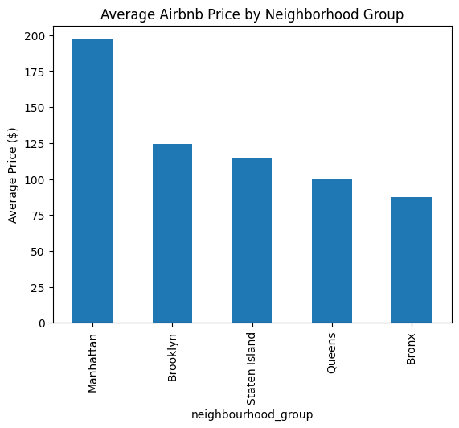

```python
# Average price by borough
neigh_group_price = df.groupby("neighbourhood_group")["price"].mean().sort_values(ascending=False)
print(neigh_group_price)

# Bar chart
import matplotlib.pyplot as plt

neigh_group_price.plot(kind="bar", title="Average Airbnb Price by Neighborhood Group")
plt.ylabel("Average Price ($)")
plt.show()
```

In cell 10, I used Matplotlib to create a bar chart visualizing the average Airbnb price by neighborhood group, helping to identify pricing trends across areas.

This bar chart shows that Manhattan has the highest average Airbnb price, close to $200, while the Bronx has the lowest, averaging under $100. Brooklyn and Staten Island fall in the middle range, followed by Queens.

```
room_type
Entire home/apt    211.794246
Private room        89.780973
Shared room         70.127586
Name: price, dtype: float64
```

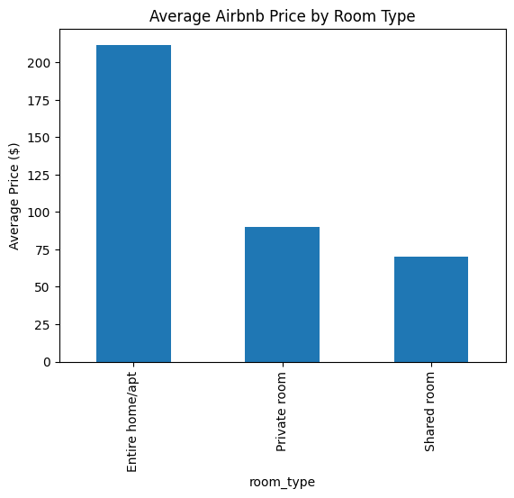

```python
# Average price by room type
room_type_price = df.groupby("room_type")["price"].mean().sort_values(ascending=False)
print(room_type_price)

# Bar chart
room_type_price.plot(kind="bar", title="Average Airbnb Price by Room Type")
plt.ylabel("Average Price ($)")
plt.show()
```

In cell 11, I used Matplotlib to create a bar chart showing the average Airbnb price by room type, highlighting pricing trends across different types of accommodations.

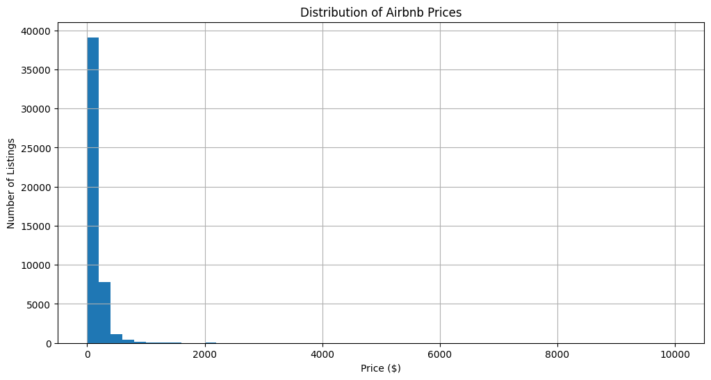

```python
#--- Distribution of prices ---
plt.figure(figsize=(12,6))
df['price'].hist(bins=50)
plt.title("Distribution of Airbnb Prices")
plt.xlabel("Price ($)")
plt.ylabel("Number of Listings")
plt.show()
```

This chart shows the overall distribution of listing prices. The majority of Airbnb rentals fall well below $2,000, with a sharp concentration under $500. The y-axis highlights just how many listings exist in these lower price ranges: tens of thousands compared to only a handful at higher prices.

**Key Insight:** Most Airbnb rentals are budget-friendly, with only a small fraction priced near the upper end of the scale. This heavy skew toward lower prices emphasizes the importance of filtering out extreme outliers when analyzing trends.

```python
# --- Boxplots to visualize price outliers ---
# Optional: limit price to $1000 for readability
df_clean = df[df['price'] < 1000]
```

```python
import seaborn as sns
```

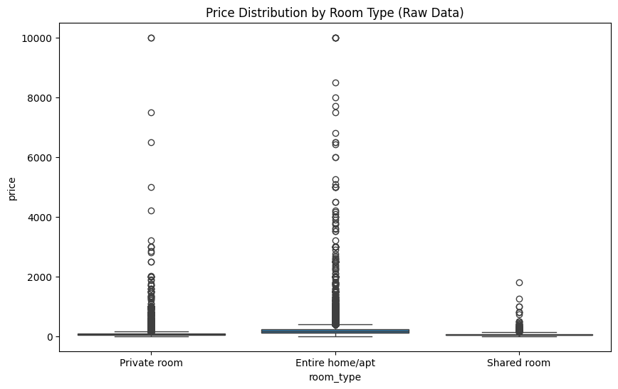

```python
plt.figure(figsize=(10,6))
sns.boxplot(x="room_type", y="price", data=df)
plt.title("Price Distribution by Room Type (Raw Data)")
plt.show()
```

Cell 21: I used a box plot to identify extreme outliers in the dataset. Many listings were priced far above the typical range, which risked distorting the analysis. To address this, I applied a cutoff at $1,000, focusing on the majority of rentals where meaningful pricing patterns emerge. This filtering improves the reliability of insights while still capturing the vast majority of real-world listings.

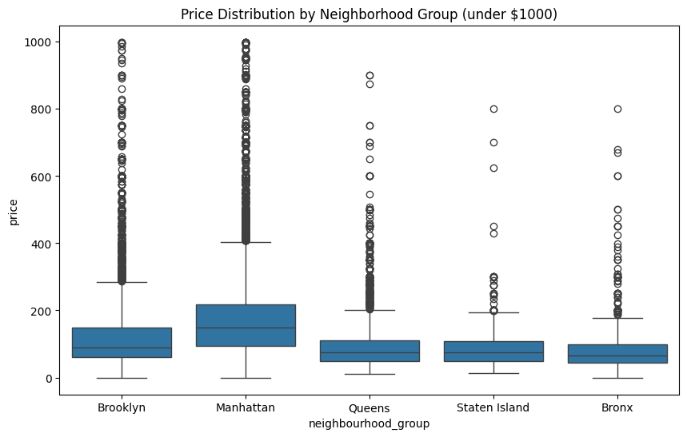

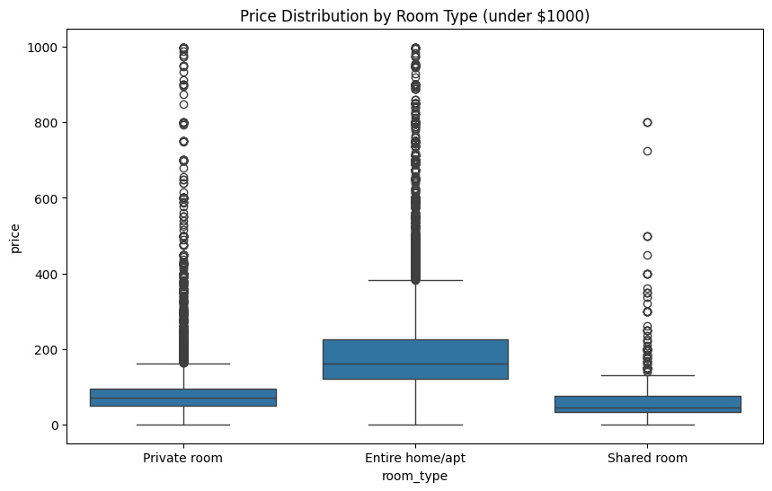

```python
# Boxplot by neighborhood group

plt.figure(figsize=(10,6))
sns.boxplot(x='neighbourhood_group', y='price', data=df_clean)
plt.title("Price Distribution by Neighborhood Group (under $1000)")
plt.show()

# Boxplot by room type
plt.figure(figsize=(10,6))
sns.boxplot(x='room_type', y='price', data=df_clean)
plt.title("Price Distribution by Room Type (under $1000)")
plt.show()
```

### Price Distributions by Location and Room Type (under $1000)

The filtered box plots reveal two major factors shaping Airbnb pricing in New York City:

- **Location**: Manhattan and Brooklyn consistently show higher median prices and wider spreads than Queens, Staten Island, and the Bronx, underscoring the premium associated with popular areas.
- **Room Type**: Entire homes/apartments command significantly higher prices than private or shared rooms, with more variability due to the presence of luxury listings.

**Key Insight:** Both *where* an Airbnb is located and *what type of room* it offers are critical determinants of price. Premium neighborhoods and full-property rentals not only drive higher median prices but also contribute to greater price variability, reflecting a mix of standard listings and high-end outliers.

### Final Summary

Through cleaning and visualizing the data, I identified two major drivers of Airbnb pricing in New York: location and room type.

Manhattan and Brooklyn consistently command higher prices with greater variability than other boroughs.

Entire homes/apartments are priced significantly above private or shared rooms.

Most listings are budget-friendly, concentrated under $500, with outliers skewing the raw distribution.

By filtering extreme outliers and focusing on the bulk of listings, the analysis provides a clearer view of typical pricing trends. These findings align with market expectations: popular locations and full-property rentals command premiums, while affordability is concentrated in private and shared rooms.